# Predict Diabetes using Ensemble Methods

# Introduction

In this project, I will use ensemble methods as well as K-folds validation techniques to classify the diabetes. The project will include the use of bagging, boosting, and 10-fold cross-validation to discover the relationship between diabetes and related attributes.

## Loading libraries and data

# 1. Exploratory Data Analysis

Firstly, I want to read the metadata and detail description provided with the data package.

```r
?PimaIndiansDiabetes
```

```
## starting httpd help server ... done
```

```r
data(PimaIndiansDiabetes)
str(PimaIndiansDiabetes)
```

```
## 'data.frame':    768 obs. of  9 variables:
##  $ pregnant: num  6 1 8 1 0 5 3 10 2 8 ...
##  $ glucose : num  148 85 183 89 137 116 78 115 197 125 ...
##  $ pressure: num  72 66 64 66 40 74 50 0 70 96 ...
##  $ triceps : num  35 29 0 23 35 0 32 0 45 0 ...
##  $ insulin : num  0 0 0 94 168 0 88 0 543 0 ...
##  $ mass    : num  33.6 26.6 23.3 28.1 43.1 25.6 31 35.3 30.5 0 ...
##  $ pedigree: num  0.627 0.351 0.672 0.167 2.288 ...
##  $ age     : num  50 31 32 21 33 30 26 29 53 54 ...
##  $ diabetes: Factor w/ 2 levels "neg","pos": 2 1 2 1 2 1 2 1 2 2 ...
```

We have 768 observations and 9 variables, 8 vaviables are numeric and 1 is factor.

Let’s take a quick look at the completeness of PimaIndiansDiabetes2 to examine how many missing values are there in the original dataset:

```r
data(PimaIndiansDiabetes2)
summary(PimaIndiansDiabetes2)
```

```
##     pregnant         glucose         pressure         triceps
##  Min.   : 0.000   Min.   : 44.0   Min.   : 24.00   Min.   : 7.00
##  1st Qu.: 1.000   1st Qu.: 99.0   1st Qu.: 64.00   1st Qu.:22.00
##  Median : 3.000   Median :117.0   Median : 72.00   Median :29.00
##  Mean   : 3.845   Mean   :121.7   Mean   : 72.41   Mean   :29.15
##  3rd Qu.: 6.000   3rd Qu.:141.0   3rd Qu.: 80.00   3rd Qu.:36.00
##  Max.   :17.000   Max.   :199.0   Max.   :122.00   Max.   :99.00
##                   NA's   :5       NA's   :35       NA's   :227
##     insulin            mass          pedigree           age
##  Min.   : 14.00   Min.   :18.20   Min.   :0.0780   Min.   :21.00
##  1st Qu.: 76.25   1st Qu.:27.50   1st Qu.:0.2437   1st Qu.:24.00
##  Median :125.00   Median :32.30   Median :0.3725   Median :29.00
##  Mean   :155.55   Mean   :32.46   Mean   :0.4719   Mean   :33.24
##  3rd Qu.:190.00   3rd Qu.:36.60   3rd Qu.:0.6262   3rd Qu.:41.00
##  Max.   :846.00   Max.   :67.10   Max.   :2.4200   Max.   :81.00
##  NA's   :374      NA's   :11
##  diabetes
##  neg:500
##  pos:268
##
##
##
##
##
```

The summary result page reveal that the variables `triceps` and `insulin` was missing too many values. `triceps` was missing 227/768 (29% of observations) and `insulin` was missing 374/768 (49% of observations). Number of missing value was too large to ignore and assign 0s.

I will use the package ‘mice’ to learn more about the missing values and perform imputation on the missing data. In order to execute proper method in the `mice` package, I will follow the tutorial provided on the website: https://www.analyticsvidhya.com/blog/2016/03/tutorial-powerful-packages-imputing-missing-values/

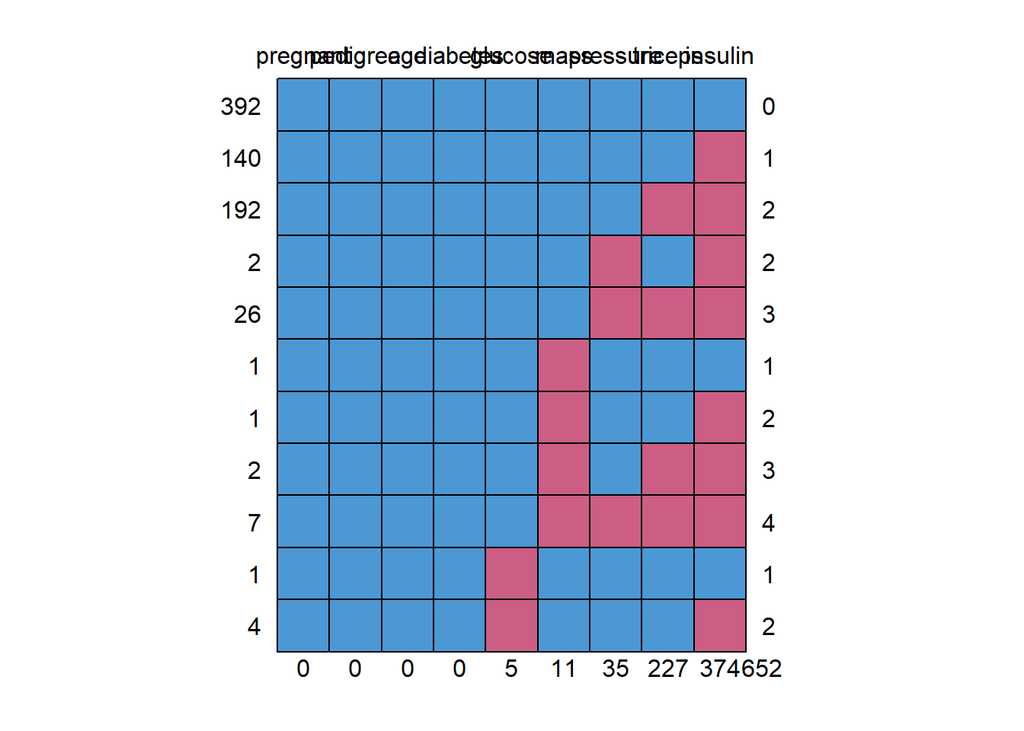

```
##     pregnant pedigree age diabetes glucose mass pressure triceps insulin
## 392        1        1   1        1       1    1        1       1       1
## 140        1        1   1        1       1    1        1       1       0
## 192        1        1   1        1       1    1        1       0       0
## 2          1        1   1        1       1    1        0       1       0
## 26         1        1   1        1       1    1        0       0       0
## 1          1        1   1        1       1    0        1       1       1
## 1          1        1   1        1       1    0        1       1       0
## 2          1        1   1        1       1    0        1       0       0
## 7          1        1   1        1       1    0        0       0       0
## 1          1        1   1        1       0    1        1       1       1
## 4          1        1   1        1       0    1        1       1       0
##            0        0   0        0       5   11       35     227     374
##
## 392   0
## 140   1
## 192   2
## 2     2
## 26    3
## 1     1
## 1     2
## 2     3
## 7     4
## 1     1
## 4     2
##     652
```

```r
library(mice)
md.pattern(PimaIndiansDiabetes2)
```

There are 392 complete observations, 140 observations with 1 missing, 192 with 2 missing and so on and so forth. Most missing values are concentrated in the `insulin` variable. I will pay close attention to this variable after imputation to make sure that the data that were used to replace missing values make sense.

In this implementation, I will remove the categorical variable `diabetes` for 2 reasons:

1. I want to use PMM (Predictive Mean Matching), a method that works for numeric variables only.
2. If I use diabetes to predict the missing values of a variable, then there is a possibility that the imputed variables will become bias when we try to predict diabetes.

```r
imputed_Data <- mice(PimaIndiansDiabetes2[-9], m = 1, method = 'pmm', seed = 500)
summary(imputed_Data)
```

```
## Class: mids
## Number of multiple imputations:  1
## Imputation methods:
## pregnant  glucose pressure  triceps  insulin     mass pedigree      age
##       ""    "pmm"    "pmm"    "pmm"    "pmm"    "pmm"       ""       ""
## PredictorMatrix:
##          pregnant glucose pressure triceps insulin mass pedigree age
## pregnant        0       1        1       1       1    1        1   1
## glucose         1       0        1       1       1    1        1   1
## pressure        1       1        0       1       1    1        1   1
## triceps         1       1        1       0       1    1        1   1
## insulin         1       1        1       1       0    1        1   1
## mass            1       1        1       1       1    0        1   1
```

We can use the imputation to complete our dataset:

```r
#get complete data ( first out of 5)
completeData <- complete(imputed_Data, 1)
```

Density plot is very useful to double check the distribution of the imputed values:

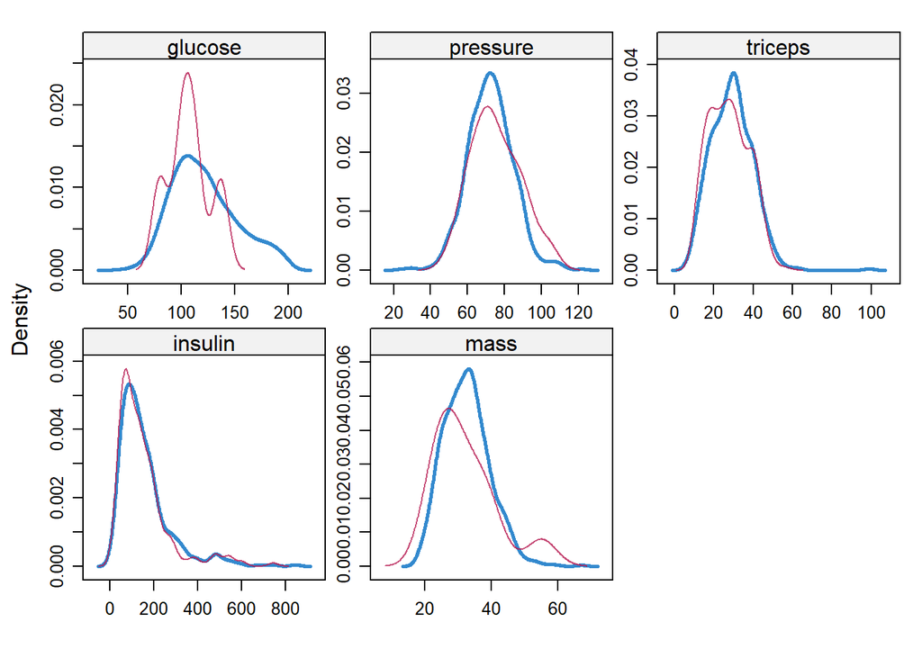

```r
densityplot(imputed_Data)
```

The complete observations is shown in blue and imputed values is shown in red. We can see that the distribution of the imputed data is very similar to the observed data, especially for the variables that we concern the most: `triceps` and `insulin`.

We can verify that the mean, median and IQR was relatively the same before and after the imputation.

```r
summary(PimaIndiansDiabetes2)
```

```
##     pregnant         glucose         pressure         triceps
##  Min.   : 0.000   Min.   : 44.0   Min.   : 24.00   Min.   : 7.00
##  1st Qu.: 1.000   1st Qu.: 99.0   1st Qu.: 64.00   1st Qu.:22.00
##  Median : 3.000   Median :117.0   Median : 72.00   Median :29.00
##  Mean   : 3.845   Mean   :121.7   Mean   : 72.41   Mean   :29.15
##  3rd Qu.: 6.000   3rd Qu.:141.0   3rd Qu.: 80.00   3rd Qu.:36.00
##  Max.   :17.000   Max.   :199.0   Max.   :122.00   Max.   :99.00
##                   NA's   :5       NA's   :35       NA's   :227
##     insulin            mass          pedigree           age
##  Min.   : 14.00   Min.   :18.20   Min.   :0.0780   Min.   :21.00
##  1st Qu.: 76.25   1st Qu.:27.50   1st Qu.:0.2437   1st Qu.:24.00
##  Median :125.00   Median :32.30   Median :0.3725   Median :29.00
##  Mean   :155.55   Mean   :32.46   Mean   :0.4719   Mean   :33.24
##  3rd Qu.:190.00   3rd Qu.:36.60   3rd Qu.:0.6262   3rd Qu.:41.00
##  Max.   :846.00   Max.   :67.10   Max.   :2.4200   Max.   :81.00
##  NA's   :374      NA's   :11
##  diabetes
##  neg:500
##  pos:268
##
##
##
##
##
```

```r
summary(completeData)
```

```
##     pregnant         glucose         pressure         triceps
##  Min.   : 0.000   Min.   : 44.0   Min.   : 24.00   Min.   : 7.00
##  1st Qu.: 1.000   1st Qu.: 99.0   1st Qu.: 64.00   1st Qu.:21.00
##  Median : 3.000   Median :117.0   Median : 72.00   Median :28.00
##  Mean   : 3.845   Mean   :121.6   Mean   : 72.54   Mean   :28.71
##  3rd Qu.: 6.000   3rd Qu.:140.2   3rd Qu.: 80.00   3rd Qu.:36.00
##  Max.   :17.000   Max.   :199.0   Max.   :122.00   Max.   :99.00
##     insulin            mass          pedigree           age
##  Min.   : 14.00   Min.   :18.20   Min.   :0.0780   Min.   :21.00
##  1st Qu.: 74.75   1st Qu.:27.48   1st Qu.:0.2437   1st Qu.:24.00
##  Median :123.50   Median :32.30   Median :0.3725   Median :29.00
##  Mean   :152.59   Mean   :32.45   Mean   :0.4719   Mean   :33.24
##  3rd Qu.:184.25   3rd Qu.:36.60   3rd Qu.:0.6262   3rd Qu.:41.00
##  Max.   :846.00   Max.   :67.10   Max.   :2.4200   Max.   :81.00
```

Now that we have a complete dataset, we can begin to perform exploratory data analysis:

```r
# return the diabetes column to out dataset
completeData$diabetes = PimaIndiansDiabetes2$diabetes

head(completeData)
```

|  | pregnant | glucose | pressure | triceps | insulin | mass | pedigree | age | diabetes |
| --- | --- | --- | --- | --- | --- | --- | --- | --- | --- |
| 1 | 6 | 148 | 72 | 35 | 285 | 33.6 | 0.627 | 50 | pos |
| 2 | 1 | 85 | 66 | 29 | 40 | 26.6 | 0.351 | 31 | neg |
| 3 | 8 | 183 | 64 | 17 | 135 | 23.3 | 0.672 | 32 | pos |
| 4 | 1 | 89 | 66 | 23 | 94 | 28.1 | 0.167 | 21 | neg |
| 5 | 0 | 137 | 40 | 35 | 168 | 43.1 | 2.288 | 33 | pos |
| 6 | 5 | 116 | 74 | 34 | 182 | 25.6 | 0.201 | 30 | neg |

### What is the correlaiton between the numerical variables?

We can determine this by calculate the correlation matrix for all numerical variables:

```r
cor(completeData[-9])
```

```
##             pregnant   glucose    pressure   triceps    insulin       mass
## pregnant  1.00000000 0.1304515  0.21853162 0.1084576 0.04596043 0.01446624
## glucose   0.13045154 1.0000000  0.22572746 0.2344698 0.57468776 0.23077943
## pressure  0.21853162 0.2257275  1.00000000 0.2288275 0.11261243 0.29123085
## triceps   0.10845765 0.2344698  0.22882746 1.0000000 0.23701208 0.65974454
## insulin   0.04596043 0.5746878  0.11261243 0.2370121 1.00000000 0.23934754
## mass      0.01446624 0.2307794  0.29123085 0.6597445 0.23934754 1.00000000
## pedigree -0.03352267 0.1399242 -0.01071528 0.1274370 0.14554639 0.15627218
## age       0.54434123 0.2692574  0.32443199 0.1559934 0.20068816 0.02586208
##             pedigree        age
## pregnant -0.03352267 0.54434123
## glucose   0.13992422 0.26925742
## pressure -0.01071528 0.32443199
## triceps   0.12743699 0.15599340
## insulin   0.14554639 0.20068816
## mass      0.15627218 0.02586208
## pedigree  1.00000000 0.03356131
## age       0.03356131 1.00000000
```

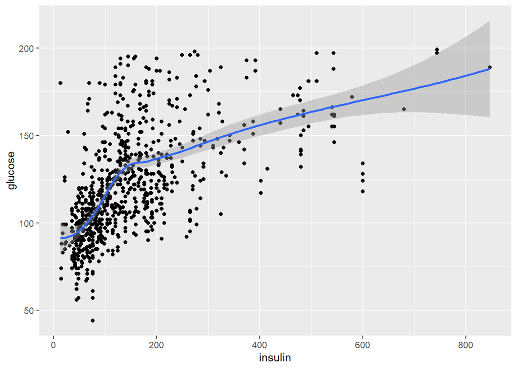

```r
# `insulin` and `glucose`
ggplot(completeData, aes(x = insulin, y = glucose)) + geom_point() + geom_smooth()
```

The relationship between `insulin` and `glucose` is perhaps can be better describe by a non-linear relationship. The blue line is an attempt to capture this non-linear relationship.

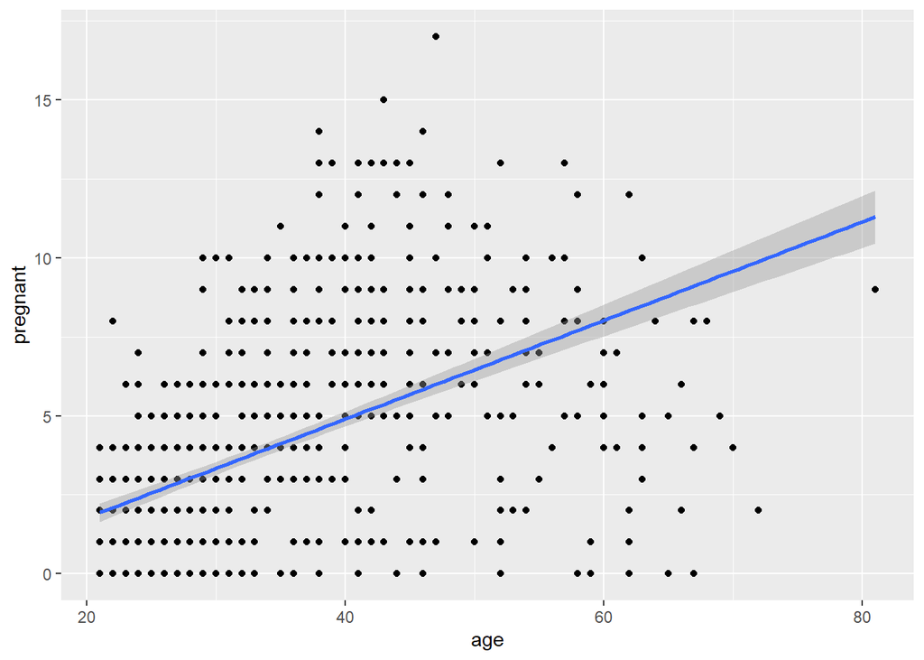

```r
# `age` and `pregnant`
ggplot(completeData, aes(x = age, y = pregnant)) + geom_point() + geom_smooth(method = "lm")
```

There is a relatively weak linear relationship between `pregnant` and `age`.

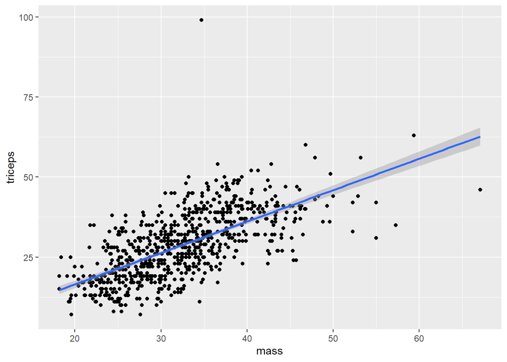

```r
# `mass` and `triceps`
ggplot(completeData, aes(x = mass, y = triceps)) + geom_point() + geom_smooth(method = "lm")
```

We can observe that there is a strong linear relationship between `triceps` and `mass`. However, there is an outlier that can potentially have high leverage on the relationship. We should take a quick look at this outlier using filter() command:

```r
completeData %>% filter(triceps > 80)
```

| pregnant | glucose | pressure | triceps | insulin | mass | pedigree | age | diabetes |
| --- | --- | --- | --- | --- | --- | --- | --- | --- |
| 2 | 197 | 70 | 99 | 744 | 34.7 | 0.575 | 62 | pos |

We can see that this outlier has relatively high glucose and is positive with diabetes. Therefore, it make sense that this person would also has thick triceps skin fold. However in reality, due to the abnormality of the value, we should check this specific case with the source to ensure data accuracy.

We can add `diabetes` label to the scatter plot of `triceps` and `mass` to see the asscociation:

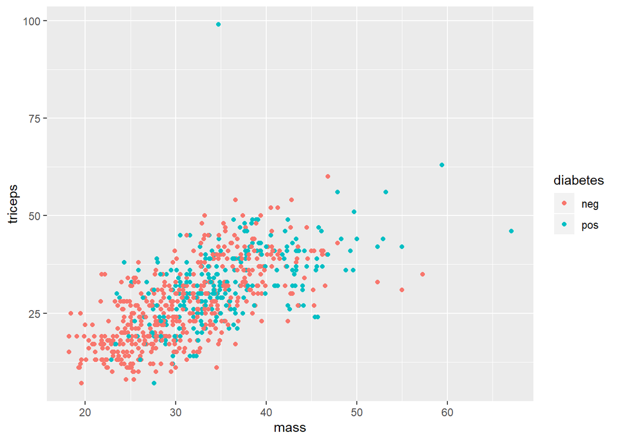

```r
ggplot(completeData, aes(x = mass, y = triceps, col = diabetes)) + geom_point()
```

We can observe that individuals diagnosed with diabetes tend to have higher `triceps` and `mass` measurement. However, there is much overlapse between the two group “neg” and “pos”. We would need much more information to be able to predict diabetes with reasonable accuracy.

Before running any machine learning algorithm to solve our problem, first we need to check the data distribution. I will use the function ggpair() from `GGAlly` package to automate this process:

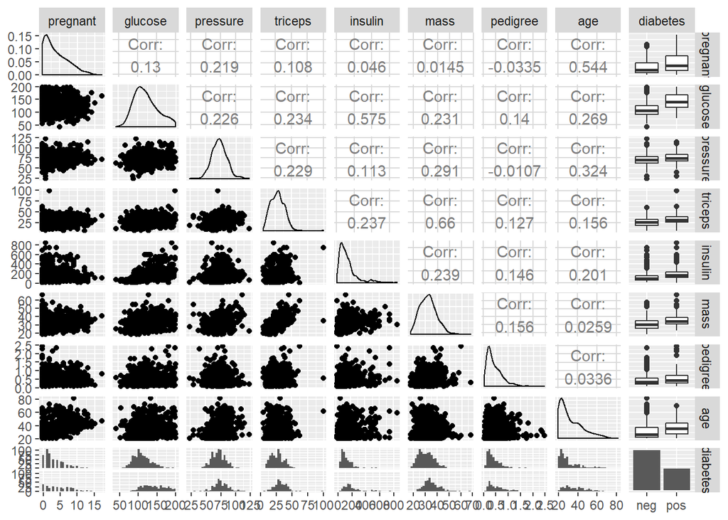

Observations about the distributions of data:

1. Numerical variables’ distrution are either normally distribution or right-skewed.
2. Diabetes has class-imbalance issue, where number of “neg” instances is way more than “pos”.

# 2. The bagging method

Create a training and a test dataset with a 80/20 split:

```r
set.seed(42)
train_index = sample(c(TRUE,FALSE), size = nrow(completeData), prob = c(0.8,0.2), replace = TRUE)
diabetes_train = completeData[train_index,]
diabetes_test = completeData[!train_index,]

# double check the number
nrow(diabetes_test)
```

```
## [1] 153
```

```r
nrow(diabetes_train)
```

```
## [1] 615
```

```r
confusionMatrix(table(bagging_prediction, diabetes_test$diabetes), positive = "pos")
```

```
## Confusion Matrix and Statistics
##
##
## bagging_prediction neg pos
##                neg  80  21
##                pos  18  34
##
##                Accuracy : 0.7451
##                  95% CI : (0.6684, 0.812)
##     No Information Rate : 0.6405
##     P-Value [Acc > NIR] : 0.003794
##
##                   Kappa : 0.4398
##
##  Mcnemar's Test P-Value : 0.748774
##
##             Sensitivity : 0.6182
##             Specificity : 0.8163
##          Pos Pred Value : 0.6538
##          Neg Pred Value : 0.7921
##              Prevalence : 0.3595
##          Detection Rate : 0.2222
##    Detection Prevalence : 0.3399
##       Balanced Accuracy : 0.7173
##
##        'Positive' Class : pos
##
```

Average error from predicted results

```r
mean(predict(mybag) != diabetes_train$diabetes)
```

```
## [1] 0.2764228
```